# Washington, DC

Jake Riley

First I will show the changes across the county from 1970-2010

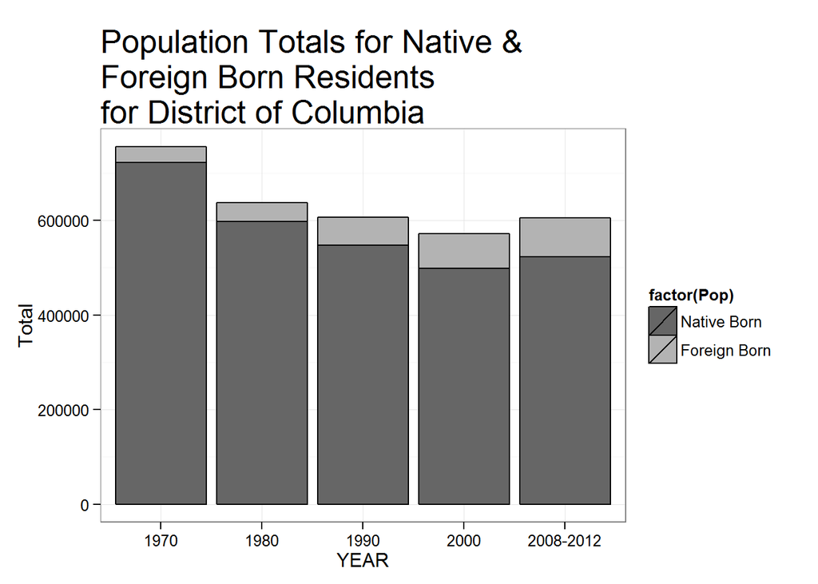

| YEAR | Total | Diff | Change |
| --- | --- | --- | --- |
| 1970 | 756492 | -118159 | -15.6% |
| 1980 | 638333 | -31433 | -4.9% |
| 1990 | 606900 | -34841 | -5.7% |
| 2000 | 572059 | 33700 | 5.9% |
| 2008-2012 | 605759 | NA | NA% |

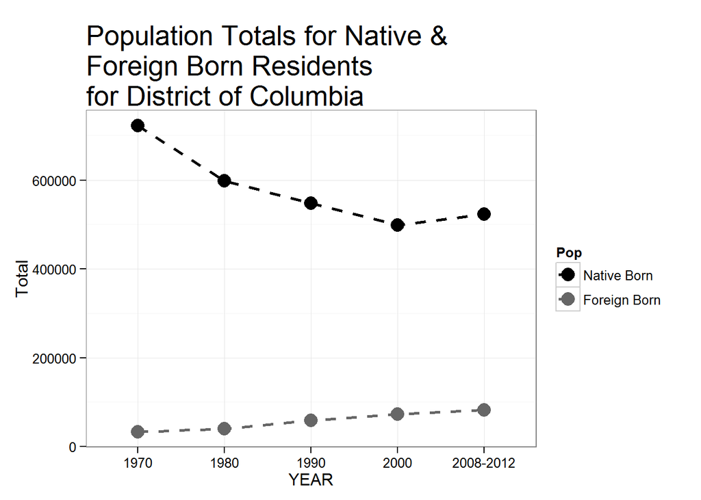

Here I break out the proportion of native born residents who are born in state vs. those born in another state.

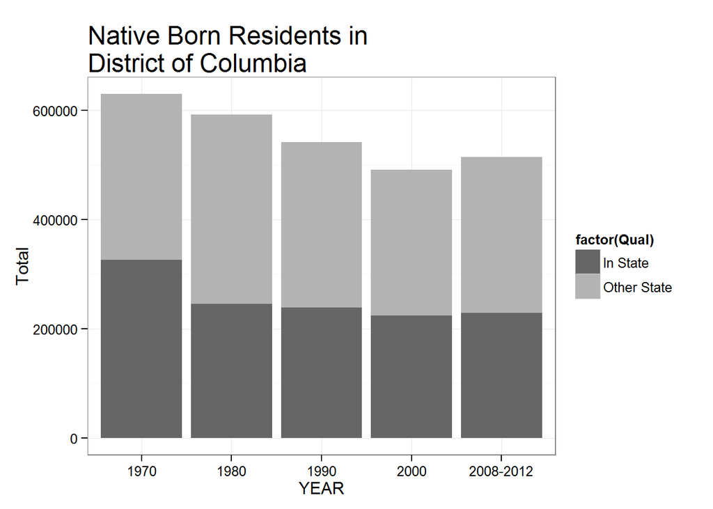

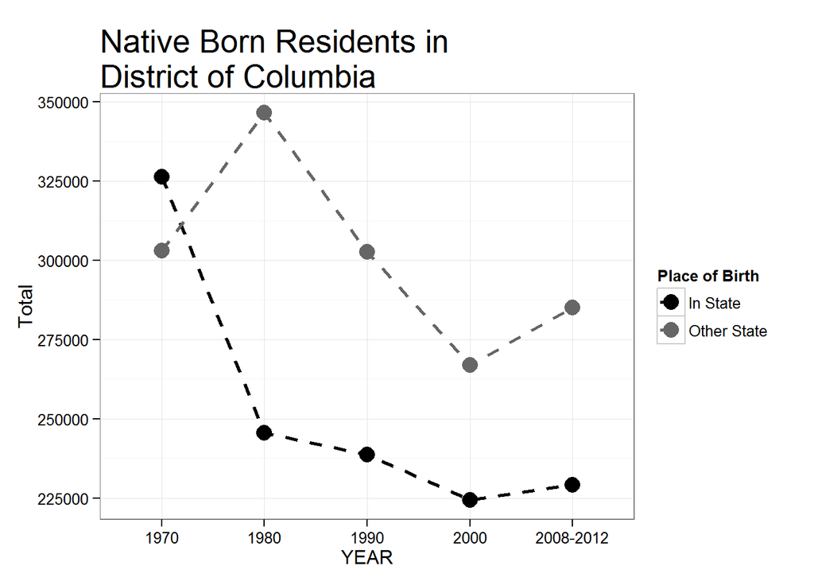

Here I look at each region separately

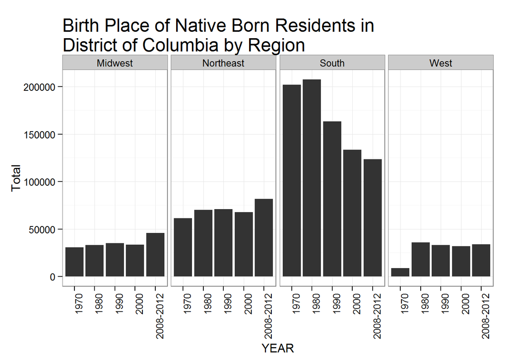

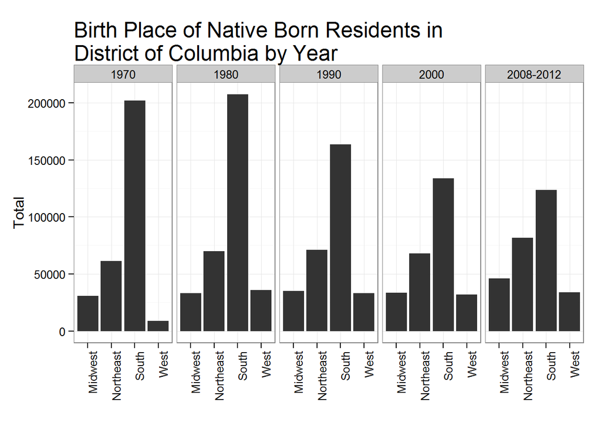

Here I look at foreign-born residents:

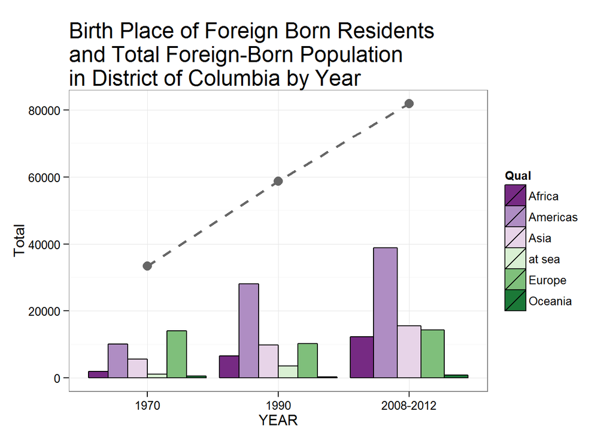

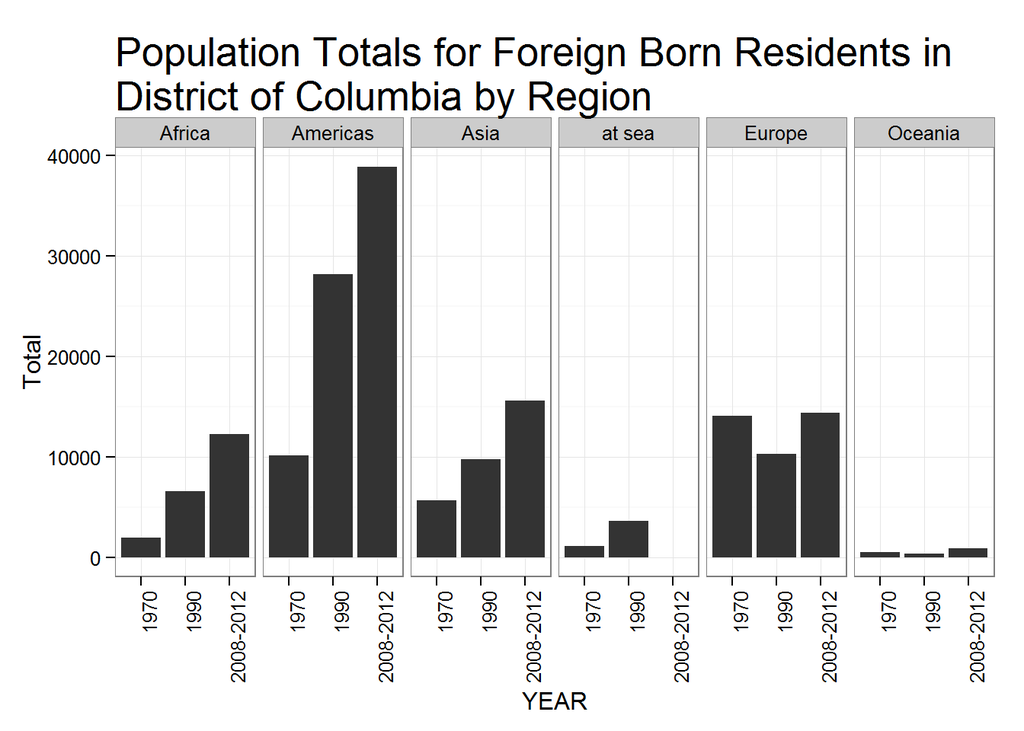

To compare tract growth, I had to create crosswalk tables from the LTDB and NHGIS data:

Merge tables

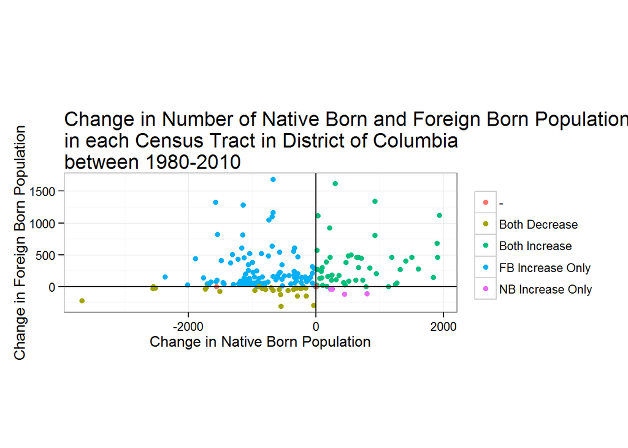

| Var1 | Freq | Pct |
| --- | --- | --- |
| - | 3 | 0.02 |
| Both Decrease | 25 | 0.14 |
| Both Increase | 49 | 0.27 |
| FB Increase Only | 99 | 0.55 |
| NB Increase Only | 4 | 0.02 |

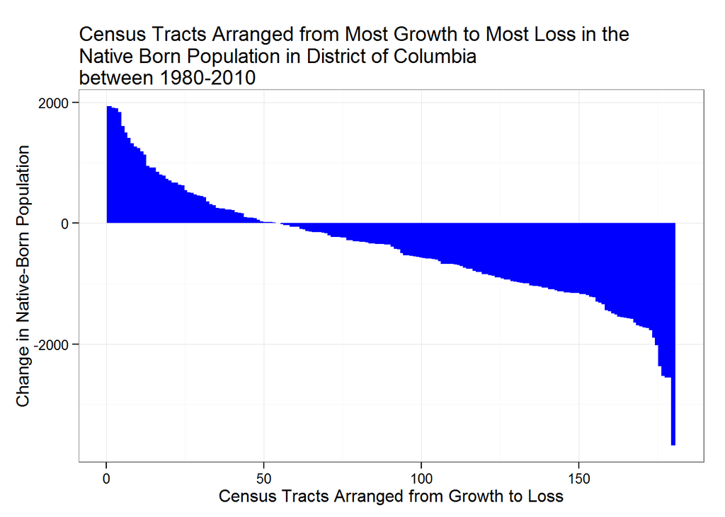

| NBDirection | Total |
| --- | --- |
| - | 0 |
| Growth | 34310 |
| Loss | -108354 |

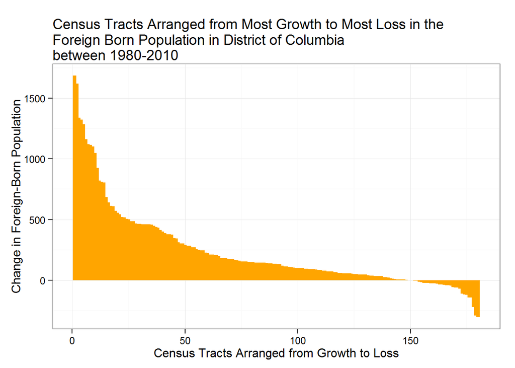

| FBDirection | Total |
| --- | --- |
| - | 0 |
| Growth | 43705 |
| Loss | -2164 |

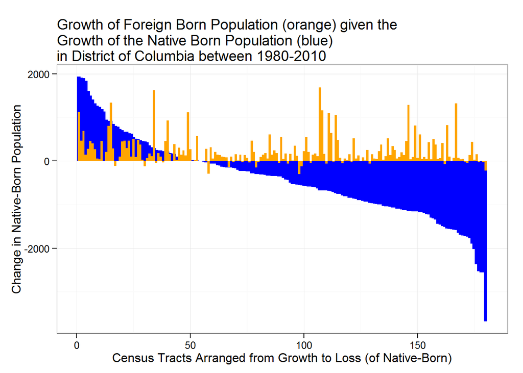

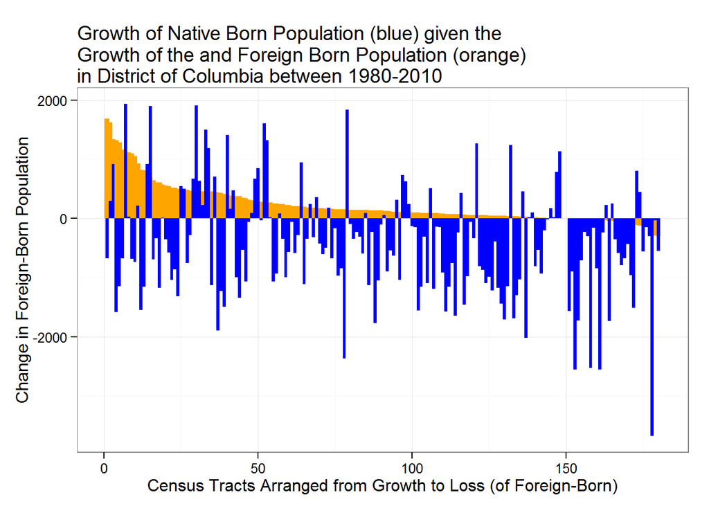

```
##
## Call:
## lm(formula = d80to10NB ~ d80to10FB, data = DistGrowth)
##
## Residuals:
##      Min       1Q   Median       3Q      Max
## -3063.14  -649.16    38.51   514.77  2288.01
##
## Coefficients:
##              Estimate Std. Error t value     Pr(>|t|)
## (Intercept) -512.3092    82.3270  -6.223 0.0000000034 ***
## d80to10FB      0.4374     0.2028   2.157       0.0323 *
## ---
## Signif. codes:  0 '***' 0.001 '**' 0.01 '*' 0.05 '.' 0.1 ' ' 1
##
## Residual standard error: 908.7 on 178 degrees of freedom
## Multiple R-squared:  0.02548,    Adjusted R-squared:   0.02
## F-statistic: 4.654 on 1 and 178 DF,  p-value: 0.03233
```

#### Median Home Values

One hypothesis about immigrant communities is that working-class immigrants move into areas where housing is more affordable. To test this, I read in the 2010 Median House Value data from the American Communty Survey and added columns for number of foreign-born (n2010FB), number of native-born (n2010NB), totoal population (TPop) and density of foreign-born (FBDensity=n2010FB/TPop).

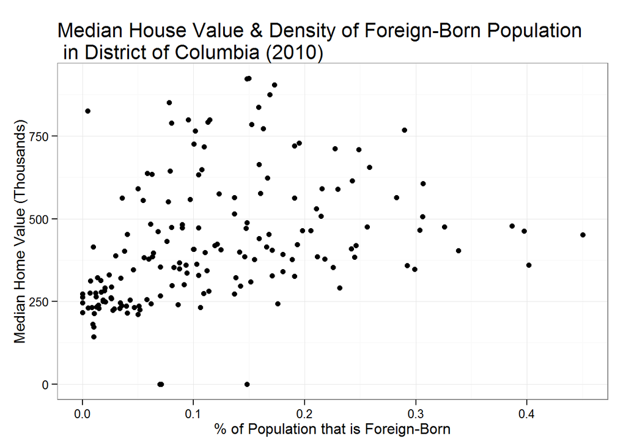

```
##
## Call:
## glm(formula = FBDensity ~ MHValue1000s, family = binomial(logit),
##     data = filter(MHValueCity, (n2010FB > 0) & (MHValue > 0)))
##
## Deviance Residuals:
##      Min        1Q    Median        3Q       Max
## -0.62506  -0.23516  -0.08343   0.14109   0.81608
##
## Coefficients:
##               Estimate Std. Error z value  Pr(>|z|)
## (Intercept)  -2.673838   0.632677  -4.226 0.0000238 ***
## MHValue1000s  0.001534   0.001228   1.249     0.212
## ---
## Signif. codes:  0 '***' 0.001 '**' 0.01 '*' 0.05 '.' 0.1 ' ' 1
##
## (Dispersion parameter for binomial family taken to be 1)
##
##     Null deviance: 13.354  on 163  degrees of freedom
## Residual deviance: 11.848  on 162  degrees of freedom
## AIC: 46.913
##
## Number of Fisher Scoring iterations: 5
```

| Pop | Std.Dev.1 | Std.Dev.2 | Std.Dev.3 |
| --- | --- | --- | --- |
| Foreign-Born | 203 | 406 | 609 |
| Native-Born | 850 | 1700 | 2550 |

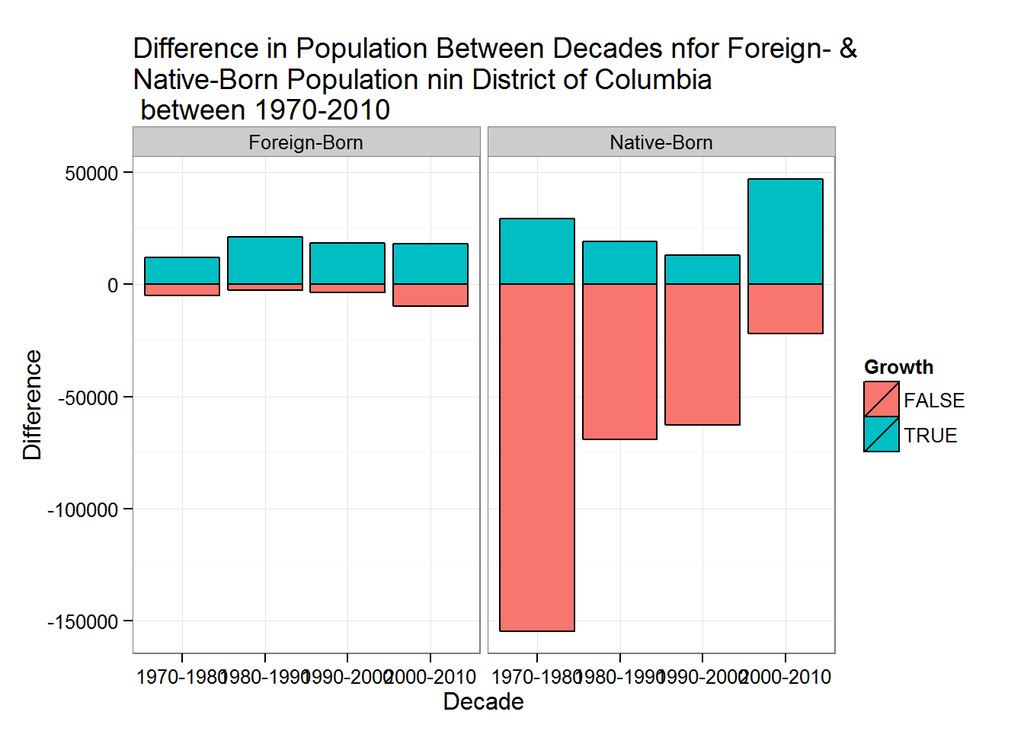

Shows the total loss and total growth between each decade for each group

| Pop | Growth | 1970-1980 | 1980-1990 | 1990-2000 | 2000-2010 |
| --- | --- | --- | --- | --- | --- |
| Foreign-Born | FALSE | -4904 | -2703 | -3694 | -9722 |
| Foreign-Born | TRUE | 12025 | 21006 | 18429 | 18225 |
| Native-Born | FALSE | -154457 | -68989 | -62590 | -21860 |
| Native-Born | TRUE | 29414 | 19234 | 13085 | 47076 |

Shows the net growth for between each decade for each group

| Pop | 1970-1980 | 1980-1990 | 1990-2000 | 2000-2010 |
| --- | --- | --- | --- | --- |
| Foreign-Born | 7121 | 18303 | 14735 | 8503 |
| Native-Born | -125043 | -49755 | -49505 | 25216 |